# 第1章 回帰モデルとスパース推定

Osamu, MORIMOTO

2023-10-12

## 3. 正則化回帰が有効でないケース。

### 準備

最初にこれから使用するパッケージを一通り呼び出しておく。

```r
if (!require("pacman")) {install.packages("pacman")} # パッケージ管理
pacman::p_load(
  conflicted,   # 関数名の衝突防止
  tidyverse,    # モダンなデータ操作
  glmnetUtils,  # 正則化回帰。テキストと違うが、こちらの方がformulaで書けるのでこちらを使う
  rsample,      # 学習データ、検証データ分割
  plotmo,       # glmnetの結果のλの変化と回帰係数の関係図
  patchwork,    # ggplot2の図をレイアウトする
  MLmetrics,    # 評価指標
  withr,        # 乱数種固定
  robustbase,   # ロバスト回帰
  summarytools, # データの概要把握（EDA）
  GGally,       # データの概要把握（EDA）
  fastDummies,  # ダミー変数生成
  janitor,      # データクリーニング
  broom         # 回帰の結果をtidyにする
  )
```

情報量規準の関数も定義しておく。

```r
ic_glmnet <- function(glmnet_model) {
  tLL <- glmnet_model$nulldev - deviance(glmnet_model)
  k <- glmnet_model$df
  n <- glmnet_model$nobs
  sig <- 2
  df <- tibble(
    lambda = glmnet_model$lambda,
    AICc = -tLL + 2 * k + 2 * k * (k + 1) / (n - k - 1),
    BIC = log(n) * k - tLL,
    Cp = (1 - glmnet_model$dev.ratio) * glmnet_model$nulldev / n + 2 * sig^2 / n * k
  )
  return(
    list(
      lambda_AICc_best = df |> slice_min(AICc) |> pull(lambda),
      lambda_BIC_best = df |> slice_min(BIC) |> pull(lambda),
      lambda_Cp_best = df |> slice_min(Cp) |> pull(lambda),
      lambda_AICc = df$AICc,
      lambda_BIC = df$BIC,
      lambda_Cp = df$Cp
      )
    )
  }
```

エラスティックネットのためのλとαの探索関数も定義。

CV版。

```r
# cva.glmnet()の出力を受け取る
get_cv_best_alpha_lambda <- function(cva_model) {
  n <- cva_model$alpha |> length()

  res <- map(
    1:n,
    \(list_no) data.frame(
      best_alpha = cva_model |> pluck("alpha", list_no),
      best_lambda = cva_model |> pluck("modlist", list_no, "lambda"),
      MSE = cva_model |> pluck("modlist", list_no, "cvm")
      )
    ) |>
    list_rbind() |>
    slice_min(MSE) |>
    dplyr::select(best_alpha, best_lambda)

  return(res)
}
```

情報量規準版。

```r
# cva.glmnet()の出力を受け取る
get_ic_best_alpha_lambda <- function(cva_model) {

  n <- cva_model$alpha |>
    length()

  ics <- map(
    1:n,
    \(list_no) cva_model |>
      pluck("modlist", list_no, "glmnet.fit") |>
      ic_glmnet()
    )

  df_ic <- map(
    1:n,
    \(list_no) data.frame(
      best_alpah = cva_model |> pluck("alpha", list_no),
      best_lambda = cva_model |> pluck("modlist", list_no, "lambda"),
      AICc = ics |> pluck(list_no, "lambda_AICc"),
      BIC = ics |> pluck(list_no, "lambda_BIC"),
      Cp = ics |> pluck(list_no, "lambda_Cp")
      )
    ) |>
    list_rbind()

  df_ic_best <- list(
    AICc_best_alpha = df_ic |> slice_min(AICc) |> pull(best_alpah),
    AICc_best_lambda = df_ic |> slice_min(AICc) |> pull(best_lambda),
    BIC_best_alpha = df_ic |> slice_min(BIC) |> pull(best_alpah),
    BIC_best_lambda = df_ic |> slice_min(BIC) |> pull(best_lambda),
    Cp_best_alpha = df_ic |> slice_min(Cp) |> pull(best_alpah),
    Cp_best_lambda = df_ic |> slice_min(Cp) |> pull(best_lambda)
  )

  return(df_ic_best)
 }
```

正則化回帰が有効でないケースについて検討する。

以下のデータセットを使う。

[LifeCycleSavings](https://stat.ethz.ch/R-manual/R-devel/library/datasets/html/LifeCycleSavings.html)

1960-1970年の貯蓄率に関するデータ。 景気サイクルやその他の短期的変動を除去するため、1960年から1970年の10年間の平均をとっている。

```r
LifeCycleSavings |>
  glimpse()
```

```
## Rows: 50
## Columns: 5
## $ sr    <dbl> 11.43, 12.07, 13.17, 5.75, 12.88, 8.79, 0.60, 11.90, 4.98, 10.78…
## $ pop15 <dbl> 29.35, 23.32, 23.80, 41.89, 42.19, 31.72, 39.74, 44.75, 46.64, 4…
## $ pop75 <dbl> 2.87, 4.41, 4.43, 1.67, 0.83, 2.85, 1.34, 0.67, 1.06, 1.14, 3.93…
## $ dpi   <dbl> 2329.68, 1507.99, 2108.47, 189.13, 728.47, 2982.88, 662.86, 289.…
## $ ddpi  <dbl> 2.87, 3.93, 3.82, 0.22, 4.56, 2.43, 2.67, 6.51, 3.08, 2.80, 3.99…
```

サマリー

```r
LifeCycleSavings |>
  dfSummary() |>
  print(method = 'render')
```

Data Frame Summary

LifeCycleSavings

**Dimensions**: 50 x 5  
**Duplicates**: 0

| **No** | **Variable** | **Stats / Values** | **Freqs (% of Valid)** | **Graph** | **Valid** | **Missing** |
| --- | --- | --- | --- | --- | --- | --- |
| 1 | sr [numeric] | Mean (sd) : 9.7 (4.5) min ≤ med ≤ max: 0.6 ≤ 10.5 ≤ 21.1 IQR (CV) : 5.6 (0.5) | 49 distinct values |  | 50 (100.0%) | 0 (0.0%) |
| 2 | pop15 [numeric] | Mean (sd) : 35.1 (9.2) min ≤ med ≤ max: 21.4 ≤ 32.6 ≤ 47.6 IQR (CV) : 17.8 (0.3) | 50 distinct values |  | 50 (100.0%) | 0 (0.0%) |
| 3 | pop75 [numeric] | Mean (sd) : 2.3 (1.3) min ≤ med ≤ max: 0.6 ≤ 2.2 ≤ 4.7 IQR (CV) : 2.2 (0.6) | 46 distinct values |  | 50 (100.0%) | 0 (0.0%) |
| 4 | dpi [numeric] | Mean (sd) : 1106.8 (990.9) min ≤ med ≤ max: 88.9 ≤ 695.7 ≤ 4001.9 IQR (CV) : 1507.4 (0.9) | 50 distinct values |  | 50 (100.0%) | 0 (0.0%) |
| 5 | ddpi [numeric] | Mean (sd) : 3.8 (2.9) min ≤ med ≤ max: 0.2 ≤ 3 ≤ 16.7 IQR (CV) : 2.5 (0.8) | 48 distinct values |  | 50 (100.0%) | 0 (0.0%) |

Generated by summarytools 1.0.1 ([R](https://www.r-project.org/) version 4.3.1)  
2023-10-12

相関

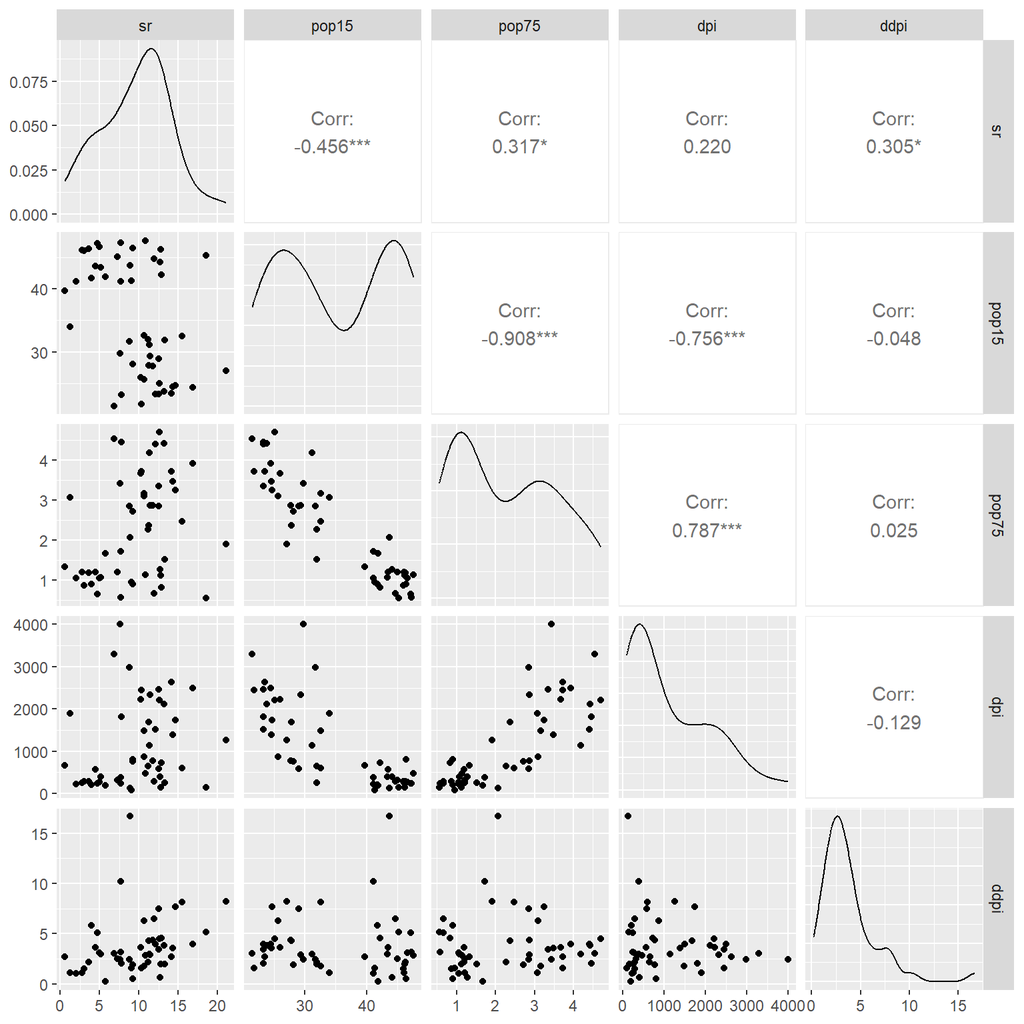

```r
LifeCycleSavings |>
  ggpairs()
```

### データ分割

学習用データと検証用データを半々に分ける。

サンプルサイズが小さすぎる、とwarningが出るが実験なのでよし

```r
LCS_split_data <- LifeCycleSavings |>
  initial_split(prop = 0.5, strata = "sr") |>
  with_seed(2, code = _)
LCS_train <- LCS_split_data |>
  training()

LCS_test <- LCS_split_data |>
  testing()
```

srを目的変数としたモデルを作る。

- 線形回帰
- 線形回帰ステップワイズ法（AIC）
- 線形回帰ステップワイズ法（BIC）
- Ridge回帰（CV）
- Ridge回帰（情報量規準）
- LASSO回帰（CV）
- LASSO回帰（情報量規準）
- 適応的LASSO回帰
- エラスティックネット回帰（CV）
- エラスティックネット回帰（情報量規準）

```r
LCS_lm <- lm(sr ~ ., data = LCS_train)

LCS_lm_aic <- LCS_lm |>
  step(direction = "backward", trace = 0) # 変数減少法

LCS_lm_bic <- LCS_lm |>
  step(direction = "backward", k = log(nrow(LCS_train)), trace = 0)

# ridge cv
LCS_ridge_cv <- cv.glmnet(sr ~ ., data = LCS_train, alpha = 0, nfolds = 5) |>
  with_seed(2, code = _)
LCS_ridge_min <- glmnet(
  sr ~ ., data = LCS_train, alpha = 0, lambda = LCS_ridge_cv$lambda.min
  )

# ridge ic
ridge_lambda_ic <- glmnet(sr ~ ., data = LCS_train, alpha = 0) |>
  ic_glmnet() #全部同じ
LCS_ridge_ic <- glmnet(
  sr ~ ., data = LCS_train, alpha = 0, lambda = ridge_lambda_ic$lambda_AICc_best
  )

# LASSO CV
LCS_lasso_cv <- cv.glmnet(sr ~ ., data = LCS_train, alpha = 1, nfolds = 5) |>
  with_seed(2, code = _)
LCS_lasso_min <- glmnet(
  sr ~ ., data = LCS_train, alpha = 1, lambda = LCS_lasso_cv$lambda.min
  )

# LASSO ic
lasso_lambda_ic <- glmnet(sr ~ ., data = LCS_train, alpha = 1) |>
  ic_glmnet() #全部同じ
LCS_lasso_ic <- glmnet(
  sr ~ ., data = LCS_train, alpha = 1, lambda = lasso_lambda_ic$lambda_AICc_best
  )

# 適応的ラッソ Adaptive Lasso
LCS_lm_std_coef <- LCS_train |>
  scale() |>
  as.data.frame() |>
  lm(sr ~ ., data = _) |>
  tidy() |>
  select(estimate) |>
  slice(-1)

LCS_alasso <- glmnet(
  sr ~ .,
  data = LCS_train,
  alpha = 1,
  penalty.factor = 1 / abs(LCS_lm_std_coef$estimate),
  lambda = 5 / nrow(LCS_train)^(3 / 4)
  )

# EN
LCS_fit_glmnet_L1L2 <- cva.glmnet(
  sr ~ .,
  data = LCS_train,
  nfolds = 5
  ) |>
  with_seed(2, code = _)

# EN CVで探索
LCS_en_cv <- LCS_fit_glmnet_L1L2 |>
  get_cv_best_alpha_lambda()

cat("CVで求めたエラスティックネットのαとλ\n")
```

```
## CVで求めたエラスティックネットのαとλ
```

```r
LCS_en_cv #alpha=0なので省略
```

| best_alpha | best_lambda |
| --- | --- |
| 0 | 1.25188 |

```r
# EN icで探索
LCS_en_ic <- LCS_fit_glmnet_L1L2 |>
  get_ic_best_alpha_lambda()

cat("情報量規準で求めたエラスティックネットのαとλ\n")
```

```
## 情報量規準で求めたエラスティックネットのαとλ
```

```r
LCS_en_ic #alpha=1なので省略
```

```
## $AICc_best_alpha
## [1] 1
##
## $AICc_best_lambda
## [1] 0.1439358
##
## $BIC_best_alpha
## [1] 1
##
## $BIC_best_lambda
## [1] 0.1439358
##
## $Cp_best_alpha
## [1] 1
##
## $Cp_best_lambda
## [1] 0.1439358
```

エラスティックネットはCVではalpha=0、情報量規準ではalpha=1となったので以降省略。

あてはまり

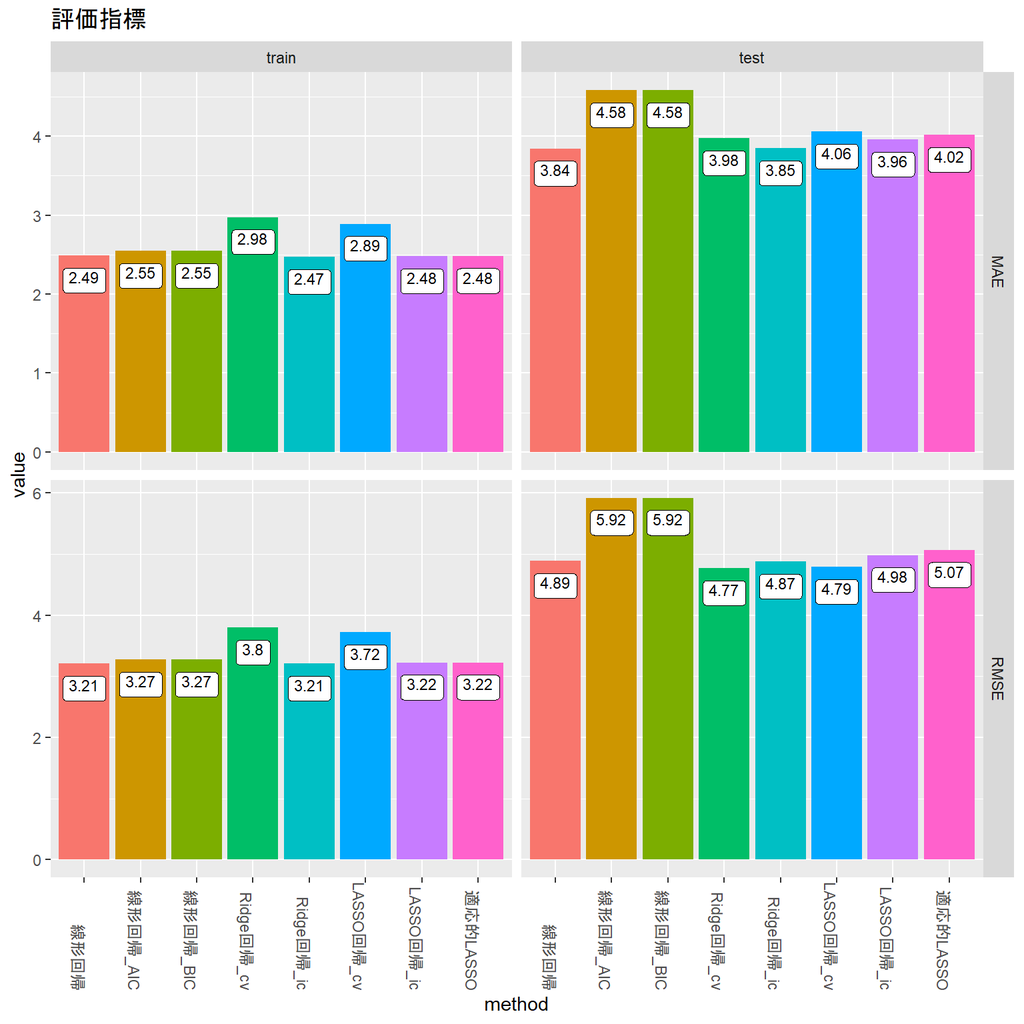

```r
models_LCS <- list(
  LCS_lm, LCS_lm_aic, LCS_lm_bic, LCS_ridge_cv, LCS_ridge_ic, LCS_lasso_cv, LCS_lasso_ic, LCS_alasso
  )

methods_LCS <- c(
  "線形回帰", "線形回帰_AIC", "線形回帰_BIC",
  "Ridge回帰_cv", "Ridge回帰_ic", "LASSO回帰_cv", "LASSO回帰_ic", "適応的LASSO"
  ) #EN

tibble(
  method = methods_LCS,
  train_MAE = models_LCS |>
    map_dbl(\(x) MLmetrics::MAE(predict(x, LCS_train), LCS_train$sr)),
  test_MAE = models_LCS |>
    map_dbl(\(x) MLmetrics::MAE(predict(x, LCS_test), LCS_test$sr)),
  train_RMSE = models_LCS |>
    map_dbl(\(x) MLmetrics::RMSE(predict(x, LCS_train), LCS_train$sr)),
  test_RMSE = models_LCS |>
    map_dbl(\(x) MLmetrics::RMSE(predict(x, LCS_test), LCS_test$sr))
) |>
  pivot_longer(!method) %>%
  mutate(
    type = stringr::str_split(.$name, "_", simplify = TRUE)[, 1] |>
      factor(levels = c("train", "test")),
    measure = stringr::str_split(.$name, "_", simplify = TRUE)[, 2] |>
      factor(levels = c("MAE", "RMSE")),
    method = method |>
      factor(levels = methods_LCS)
  ) |>
  ggplot(aes(x = method, y = value, group = 1, label = round(value, 2))) +
  geom_col(aes(fill = method)) +
  geom_label(size = 3, vjust = 1.5) +
  facet_grid(vars(measure), vars(type), scales = "free") +
  labs(title = "評価指標") +
  theme(
    axis.text.x = element_text(angle = 270, hjust = 1),
    legend.position = "none"
  )
```

通常の線形回帰とほとんど変わらないか悪化している。

Ridgeは悪くないけど、素晴らしいというほどではない。

正則化すれば必ず良くなるというわけではない

とはいえ、従来のAIC、BICによる変数選択はダメ。

#### シミュレーションであてはまりの安定性を確認

関数定義

```r
sim_f_LCS <- function() {
  # データ分割（乱数固定しない）
  LCS_split_data <- LifeCycleSavings |>
    initial_split(prop = 0.5, strata = "sr")
  LCS_train <- LCS_split_data |> training()
  LCS_test <- LCS_split_data |> testing()

  # モデリング
  LCS_lm <- lm(sr ~ ., data = LCS_train)

  LCS_lm_aic <- LCS_lm |>
    step(direction = "backward", trace = 0) # 変数減少法

  LCS_lm_bic <- LCS_lm |>
    step(direction = "backward", k = log(nrow(LCS_train)), trace = 0)

  LCS_ridge_cv <- cv.glmnet(sr ~ ., data = LCS_train, alpha = 0)  # Ridge
  LCS_ridge_min <- glmnet(
    sr ~ ., data = LCS_train, alpha = 0, lambda = LCS_ridge_cv$lambda.min
    )

  # ridge ic
  ridge_lambda_ic <- glmnet(sr ~ ., data = LCS_train, alpha = 0) |>
    ic_glmnet()
  LCS_ridge_aicc <- glmnet(
    sr ~ ., data = LCS_train, alpha = 0, lambda = ridge_lambda_ic$lambda_AICc_best
    )
  LCS_ridge_bic <- glmnet(
    sr ~ ., data = LCS_train, alpha = 0, lambda = ridge_lambda_ic$lambda_BIC_best
    )
  LCS_ridge_cp <- glmnet(
    sr ~ ., data = LCS_train, alpha = 0, lambda = ridge_lambda_ic$lambda_Cp_best
    )

  LCS_lasso_cv <- cv.glmnet(sr ~ ., data = LCS_train, alpha = 1)
  LCS_lasso_min <- glmnet(
    sr ~ ., data = LCS_train, alpha = 1, lambda = LCS_lasso_cv$lambda.min
    )

  # LASSO ic
  lasso_lambda_ic <- glmnet(sr ~ ., data = LCS_train, alpha = 1) |>
    ic_glmnet()
  LCS_lasso_aic <- glmnet(
    sr ~ ., data = LCS_train, alpha = 1, lambda = lasso_lambda_ic$lambda_AICc_best
    )
  LCS_lasso_bic <- glmnet(
    sr ~ ., data = LCS_train, alpha = 1, lambda = lasso_lambda_ic$lambda_BIC_best
    )
  LCS_lasso_cp <- glmnet(
    sr ~ ., data = LCS_train, alpha = 1, lambda = lasso_lambda_ic$lambda_Cp_best
    )

  # 適応的ラッソ Adaptive Lasso
  LCS_lm_std_coef <- LCS_train |>
    scale() |>
    as.data.frame() |>
    lm(sr ~ ., data = _) |>
    tidy() |>
    select(estimate) |>
    slice(-1)

  LCS_alasso <- glmnet(
    sr ~ .,
    data = LCS_train,
    alpha = 1,
    penalty.factor = 1 / abs(LCS_lm_std_coef$estimate),
    lambda = 5 / nrow(LCS_train)^(3 / 4)
    )

  ###### 評価
  models_LCS <- list(
    LCS_lm,
    LCS_lm_aic,
    LCS_lm_bic,
    LCS_ridge_min,
    LCS_ridge_aicc,
    LCS_ridge_bic,
    LCS_ridge_cp,
    LCS_lasso_min,
    LCS_lasso_aic,
    LCS_lasso_bic,
    LCS_lasso_cp,
    LCS_alasso
  )

  df <- data.frame(
    methods = c(
      "線形回帰", "線形回帰_stepwise_AIC", "線形回帰_stepwise_BIC",
      "Ridge回帰_cv", "Ridge回帰_AICc", "Ridge回帰_BIC", "Ridge回帰_Cp",
      "LASSO回帰_cv", "LASSO回帰_AICc", "LASSO回帰_BIC", "LASSO回帰_Cp",
      "適応的LASSO"),
    RMSE = models_LCS |>
      map_dbl(\(x) MLmetrics::RMSE(predict(x, LCS_test), LCS_test$sr)),
    MAE = models_LCS |>
      map_dbl(\(x) MLmetrics::MAE(predict(x, LCS_test), LCS_test$sr))
  )

  return(df)
}
```

実行。300回試行。

```r
j <- 300
sim_data <- map(1:j, \(x) sim_f_LCS()) |> #, .progress = TRUE
  list_rbind()
```

結果

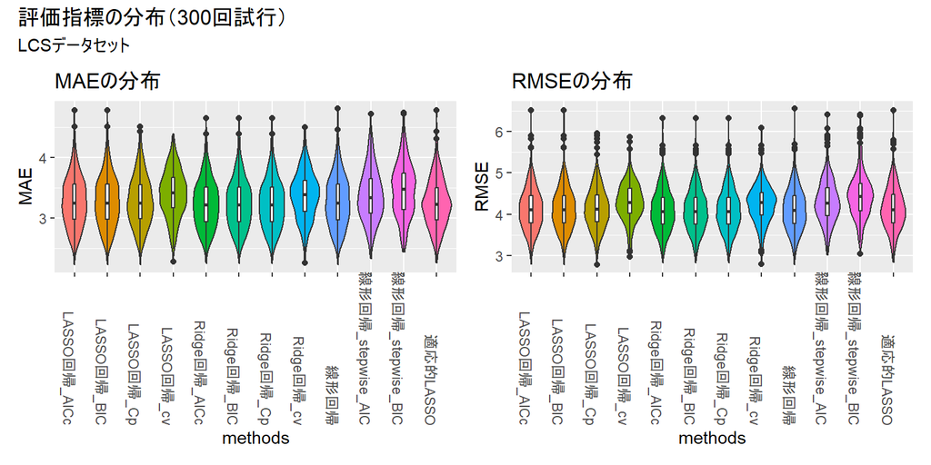

```r
p1 <- sim_data |>
  ggplot(aes(x = methods, y = MAE)) +
  geom_violin(aes(fill = methods)) +
  geom_boxplot(width = 0.1) +
  labs(title = "MAEの分布") +
  theme(
    axis.text.x = element_text(angle = 270, hjust = 1),
    legend.position = "none"
  )

p2 <- sim_data |>
  ggplot(aes(x = methods, y = RMSE)) +
  geom_violin(aes(fill = methods)) +
  geom_boxplot(width = 0.1) +
  labs(title = "RMSEの分布") +
  theme(
    axis.text.x = element_text(angle = 270, hjust = 1),
    legend.position = "none"
  )

p1 + p2 +
  plot_annotation(title = "評価指標の分布（300回試行）", subtitle = "LCSデータセット")
```

どれも変わらん。つまり普通の線形回帰で十分。

TOPへ戻る